# Time Profile Plot Vignette

OSPSuiteR 2019

2019-10-29

# Introduction

The aim of this vignette is to illustrate the workflow for producing time profile plots using the `tlf`-Library.

## Libraries

The main purpose of the `tlf`-library is to standardized the production of `ggplot` objects from data output by `OSPSuiteR`. As such, `tlf`-library requires that the `ggplot2` package be installed.

The suggested workflow for performing any kind of plot with the `tlf`-library is illustrated in the figure below.

## `tlf` workflow

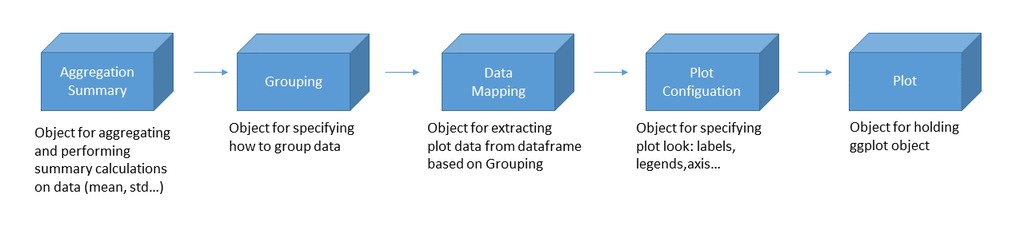

The standard workflow then proceeds as follows:

**Step 0 - Data gathering.** Gather the data into tidy dataframe format.

**Step 1 - Data pre-processing** Pre-process the data using `AggregationSummary` class.

**Step 2 - Data grouping** Use the `Groupings` class to specify groupings according to which the data will be captioned in figure legends.

**Step 3 - Data mapping.** Use the `DataMapping` class to select the independent and dependent variables of the processed data as well as the aesthetics that will be used to differentiate between the groupings of the data that were specified in step 2.

**Step 4 - Plot configuration** Set the `PlotConfiguration` object which will define settings of the plot such as axis labeling, font sizes and watermarks.

**Step 5 - Plot generation** Create a `ggplot` object from the above classes using the dedicated plotting function.

Steps 1, 2, 3 and 4 are not mandatory. If not implemented, `tlf`-libray uses default settings in lieu of the objects that are otherwise created in these optional steps. In addition, the `PlotConfiguration` object and the `DataMapping` object can be created independently.

### A minimal example

Before presentation of the full functionality of `tlf` classes, the following minimal example of a time profile plot will demonstrate the workflow for producing a `ggplot` image using Steps 0, 2, 3 and 5.

**Example Step 0:** The data to be plotted in `tlf` is assumed to be in R dataframe format. An example such dataframe is the following, which contains time profile concentration data for two individuals. Each individual is allocated a unqiue indentifier in the column *IndividualID*.

```r
minimalDataFrame <- data.frame("Time"=c(0,1,2,0,1,2),
                               "IndividualID"=as.factor(c(1,1,1,2,2,2)),
                               "Concentration"=c(3,4,5,4,5,6))
pander::pandoc.table(minimalDataFrame)
```

| Time | IndividualID | Concentration |
| --- | --- | --- |
| 0 | 1 | 3 |
| 1 | 1 | 4 |
| 2 | 1 | 5 |
| 0 | 2 | 4 |
| 1 | 2 | 5 |
| 2 | 2 | 6 |

**Example Step 2:** In this step, groupings of the data are specified. In this simple example, each individual’s measurements are to be plotted using different linetypes. A `Grouping` object is therefore created that specifies that a graph with a different *linetype* is to be used to plot the points for each unique value of the *IndividualID* column.

```r
minimalGrouping <- tlf:::Groupings$new( linetype = "IndividualID" )
```

The construction of more detailed groupings is discussed in the Groupings section below.

**Example Step 3:** Here, the independent and dependent variables of the plot and the plot groupings are specified using a `TimeProfileDataMapping` object, which is a subclass of the DataMapping class specifically aimed at producing time profile plots. The constructor of this class identifies the *Time* column of the dataframe as the time axis, the *Concentration* column of the dataframe as the vertical axis, and `minimalGrouping`, which was defined in the earlier step, as the grouping object to use.

```r
minimalDataMapping <-TimeProfileDataMapping$new(x = "Time",
                                                y = "Concentration",
                                                groupings = minimalGrouping)
```

**Example Step 5:** In the final step of this example, a `ggplot` object called `timeProfilePlot` is created using the `plotTimeProfile` function:

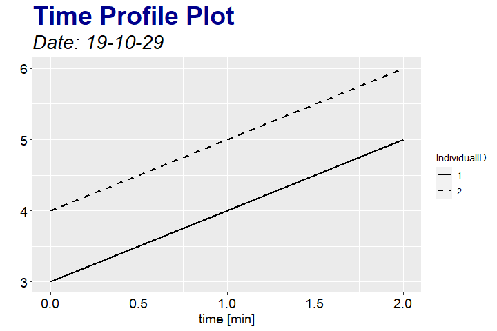

```r
timeProfilePlot<-plotTimeProfile(data = minimalDataFrame , dataMapping = minimalDataMapping)
show(timeProfilePlot)
```

# 0. Data gathering

## The dataset

In the sequel, the data that will be used for the time profile plot is the following `data.frame` variable named `timeProfileDataFrame`:

```r
# Data frame printed in a nice markdown table:
pander::pandoc.table(timeProfileDataFrame[,c("IndividualID", "Time", "Population" ,  "Gender", "Age", "Compound" , "Dose"  , "Simulated")], justify='center', round=2)
```

| IndividualID | Time | Population | Gender | Age | Compound | Dose | Simulated |
| --- | --- | --- | --- | --- | --- | --- | --- |
| 1 | 0 | European | M | 7 | Aspirin | 6 | 2.19 |
| 2 | 0 | European | F | 5 | Aspirin | 6 | 5.47 |
| 3 | 0 | Asian | M | 8 | Sugar | 6 | 2.38 |
| 4 | 0 | Asian | F | 6 | Aspirin | 3 | 3.48 |
| 1 | 1 | European | M | 7 | Aspirin | 6 | 5.47 |
| 2 | 1 | European | F | 5 | Aspirin | 6 | 6.14 |
| 3 | 1 | Asian | M | 8 | Sugar | 6 | 5.88 |
| 4 | 1 | Asian | F | 6 | Aspirin | 3 | 7.6 |
| 1 | 2 | European | M | 7 | Aspirin | 6 | 12.35 |
| 2 | 2 | European | F | 5 | Aspirin | 6 | 9.7 |
| 3 | 2 | Asian | M | 8 | Sugar | 6 | 9.19 |
| 4 | 2 | Asian | F | 6 | Aspirin | 3 | 18.66 |

The workflow assumes that the data to be plotted has been gathered in the form of a [*tidy*](https://cran.r-project.org/web/packages/tidyr/vignettes/tidy-data.html) dataframe. In a tidy format dataframe, each *measurement*, such as a simulation result or experimental observation, is described entirely in one row. The columns of the dataframe are limited to no more than the *independent variable* columns of the measurement (in this example, *Time* and *IndividualID*) and the *dependent variable* columns (in this case *Simulated*), which hold the value of the measurement. Since no additional columns are allowed, two dependent variables that have differing sets of independent variables should each have their own tidy dataframes.

## MetaData

A `metaData` variable associated with the data can be used to define additional information such as the `dimension` and `units` of each column in the `data.frame`. The lower limit of quantitiation of time profile data can also be stored in the `metaData`.

```r
timeProfileMetaData<-list("Time"        =list(unit = "min",  dimension = "Time"         ),
                          "IndividualID"=list(unit = NULL,   dimension = NULL           ),
                          "Population"  =list(unit = NULL,   dimension = NULL           ),
                          "Gender"      =list(unit = NULL,   dimension = NULL           ),
                          "Age"         =list(unit = "yrs",  dimension = "Time"         ),
                          "Compound"    =list(unit = NULL,   dimension = NULL           ),
                          "Dose"        =list(unit = "mg",   dimension = "Amount"       ),
                          "Organ"       =list(unit = NULL,   dimension = NULL           ),
                          "Compartment" =list(unit = NULL,   dimension = NULL           ),
                          "Simulated"   =list(unit = "mg/L", dimension = "Concentration"))
```

# 1. Data pre-processing

The `R6` class `AggregationSummary` automates the computation of multiple summary statistics of the raw data that is output by **Step 0**. The output of this optional data pre-processing step is a dataframe with a column for each summary statistic. This dataframe can be input into the subsequent steps of the workflow. The user also has the option of generating `metaData` for each of the summary statistics evaluated.

To illustrate the function of this class for the example of the dataframe `timeProfileDataFrame`, suppose that for each timepoint in the *Time* column, the *minimum* and the *mean* value of the *Simulated* column is to be computed for each gender in the *Gender* column. The `AggregationSummary` class works in three steps:

1. Three sets of columns are selected from the input dataframe `data`: an *independent variable* set called `xColumnNames` (in this case, the *Time* column in `timeProfileDataFrame`), a *grouping variables* set called `groupingColumnNames` (the *Gender* column in `timeProfileDataFrame`) and a *dependent variables* set called `yColumnNames` (the *Simulated* column in `timeProfileDataFrame`).
2. For each value of the independent variable `xColumnNames`, the rows of the dataframe are aggregated into groups defined by unique combinations of the elements in the grouping variable columns `groupingColumnNames`.
3. Summary statistics (in this case, the minimum and the mean) for the `yColumnNames` variables in each group are evaluated. The functions for computing the the summary statistics are specified when initializing an `AggregationSummary`, via `aggregationFunctionsVector`. User-specified descriptive names of these functions are supplied via the vector of strings named `aggregationFunctionNames`. The units and dimensions of the outputs of these functions are supplied via the vectors of strings named `aggregationUnitsVector` and `aggregationDimensionsVector`, respectively.

For this example, the `AggregationSummary` object `aggSummary` is instatiated as follows:

```r
aggSummary <- AggregationSummary$new(data = timeProfileDataFrame ,
                                     metaData = timeProfileMetaData,
                                     xColumnNames = "Time",
                                     groupingColumnNames = "Gender",
                                     yColumnNames = "Simulated",
                                     aggregationFunctionsVector = c(min,mean),
                                     aggregationFunctionNames =c("Simulated Min",
                                                                 "Simulated Mean"),
                                     aggregationUnitsVector = c("mg/L","mg/L"),
                                     aggregationDimensionsVector = c("Concentration",
                                                                     "Concentration"))
```

The dataframe that holds the summary statistics of the aggregated rows is stored in the `dfHelper` property of the resulting `aggSummary` object. Since two functions (`min` and `mean`) were specified in `aggregationFunctionsVector`, the dataframe `aggSummary$dfHelper` has, in addition to the `xColumnNames`and `groupingColumnNames` columns, two additional columns named `Simulated Min` and `Simulated Mean`, which were the names specified in `aggregationFunctionNames`.

```r
pander::pandoc.table(aggSummary$dfHelper, round=2)
```

| Time | Gender | Simulated Min | Simulated Mean |
| --- | --- | --- | --- |
| 0 | F | 3.48 | 4.48 |
| 1 | F | 6.14 | 6.87 |
| 2 | F | 9.7 | 14.18 |
| 0 | M | 2.19 | 2.28 |
| 1 | M | 5.47 | 5.68 |
| 2 | M | 9.19 | 10.77 |

The `metaData` corresponding to the columns of the resulting dataframes are lists that are stored together in a list with the `metaData` of the `xColumnNames`and `groupingColumnNames` columns. The `metaData` for the new `aggSummary$dfHelper` dataframe is stored as the `metaDataHelper` property of the `aggSummary` object. For this example, the two `metaData` lists corresponding to the `Simulated Min` and `Simulated Mean` columns are also are labeled `Simulated Min` and `Simulated Mean`. The contents of the list `aggSummary$metaDataHelper` are:

```
    * **Time**:

      * **unit**: min
      * **dimension**: Time

  * **Gender**:

      * **unit**:
      * **dimension**:

  * **Simulated Min**:

      * **unit**: mg/L
      * **dimension**: Concentration

  * **Simulated Mean**:

      * **unit**: mg/L
      * **dimension**: Concentration
```

## Groupings

An `R6` class called `GroupMapping` can be used to group the data into subsets that, in the final plots, are to be distinguished both aesthetically and in legend captions. In addition, these subsets can be listed under descriptive legend titles.

As an example, a `GroupMapping` object called `grouping1` can be used to specify that the data in a *tidy* dataframe such as `timeProfileDataFrame` should be grouped by both “Compound” and “Dose”:

```r
# Grouping by variable names:
grouping1 <- GroupMapping$new(c("Compound","Dose"))
```

With this minimal input, a legend associated with this grouping will have the default title “Compound-Dose”. On the other hand, a custom title for this grouping and its legend can be supplied by the user with the optional `label` input:

```r
# Grouping by variable names and overwriting the default label:
grouping2 <- GroupMapping$new(c("Compound","Dose"), label = "Compound & Dose")
```

In the above two examples, default captions are constructed by hyphenating the compound type and the dose amount for each row. Alternatively, the captions can be customized by the user by supplying a dataframe with the custom captions to the `group` input of the `GroupMapping` object constructor. The format of this dataframe is such that the rightmost column contains the desired captions, the name of this rightmost column is the default legend title for this grouping, and the remaining columns define the combinations of row entries that are to receive each caption in the rightmost column. To illustrate this method, the following dataframe `mappingDataFrame` is used to assign captions based on entries in the “Dose” and “Compound” columns. For example the caption “6mg of Aspirin” is assigned to any row in which the “Dose” entry is 6 and the “Compound” entry is “Aspirin”.

```r
# Grouping using a data.frame:
mappingDataFrame <- data.frame(Compound = c("Aspirin","Aspirin","Sugar","Sugar"),
                               Dose = c(6,3,6,3),
                               "Compound & Dose"  = c("6mg of Aspirin",
                                                      "3mg of Aspirin",
                                                      "6mg of Sugar",
                                                      "3mg of Sugar"),
                               check.names = FALSE)
pander::pandoc.table(mappingDataFrame)
```

| Compound | Dose | Compound & Dose |
| --- | --- | --- |
| Aspirin | 6 | 6mg of Aspirin |
| Aspirin | 3 | 3mg of Aspirin |
| Sugar | 6 | 6mg of Sugar |
| Sugar | 3 | 3mg of Sugar |

```r
grouping3 <- GroupMapping$new(group = mappingDataFrame)
```

The default title of the legend that results from this grouping is the name of the rightmost column, which is “Compound & Dose”. Note that the `check.names` option should be set to `FALSE` when creating the dataframe `mappingDataFrame` since the legend title contains spaces in this instance. This legend title can be overridden to be another string by using the `label` input of the object constructor, as in the case of `grouping2` above.

The three `GroupMapping` objects, `grouping1`, `grouping2` and `grouping3` respectively yield the last three columns of the following dataframe:

```r
# Apply the mapping to get the grouping captions:
groupingsDataFrame <- data.frame(timeProfileDataFrame$IndividualID,
                                 timeProfileDataFrame$Dose,
                                 timeProfileDataFrame$Compound,
                                 grouping1$getCaptions(timeProfileDataFrame),
                                 grouping2$getCaptions(timeProfileDataFrame),
                                 grouping3$getCaptions(timeProfileDataFrame))

names(groupingsDataFrame) <- c("IndividualID", "Dose", "Compound",
                               grouping1$label, grouping2$label, grouping3$label)

# Show results for all groupings:
pander::pandoc.table(groupingsDataFrame)
```

| IndividualID | Dose | Compound | Compound-Dose | Compound & Dose | Compound & Dose |
| --- | --- | --- | --- | --- | --- |
| 1 | 6 | Aspirin | Aspirin-6 | Aspirin-6 | 6mg of Aspirin |
| 2 | 6 | Aspirin | Aspirin-6 | Aspirin-6 | 6mg of Aspirin |
| 3 | 6 | Sugar | Sugar-6 | Sugar-6 | 6mg of Sugar |
| 4 | 3 | Aspirin | Aspirin-3 | Aspirin-3 | 3mg of Aspirin |
| 1 | 6 | Aspirin | Aspirin-6 | Aspirin-6 | 6mg of Aspirin |
| 2 | 6 | Aspirin | Aspirin-6 | Aspirin-6 | 6mg of Aspirin |
| 3 | 6 | Sugar | Sugar-6 | Sugar-6 | 6mg of Sugar |
| 4 | 3 | Aspirin | Aspirin-3 | Aspirin-3 | 3mg of Aspirin |
| 1 | 6 | Aspirin | Aspirin-6 | Aspirin-6 | 6mg of Aspirin |
| 2 | 6 | Aspirin | Aspirin-6 | Aspirin-6 | 6mg of Aspirin |
| 3 | 6 | Sugar | Sugar-6 | Sugar-6 | 6mg of Sugar |
| 4 | 3 | Aspirin | Aspirin-3 | Aspirin-3 | 3mg of Aspirin |

A dataframe can also be used to create a `GroupMapping` object that subsets the data based on whether a numeric grouping variable satisfies an specific inequality. For example, individuals in `timeProfileDataFrame` can be grouped according to whether or not their age exceeds 6 years by first defining the following dataframe:

```r
# Grouping using a data.frame:
binningDataFrame <- data.frame(Age = I( list(c(0,6),c(7,100)) ),
                               "Age Range" = c("Age 6 or lower",
                                               "Above age 6"),
                               check.names = FALSE)
```

Then creating a new grouping:

```r
grouping4 <- GroupMapping$new(group = binningDataFrame)
```

This new `GroupMapping` object `grouping4` yields the following captions

```r
# Apply the mapping to get the grouping captions:
binnedGroupingsDataFrame <- data.frame(timeProfileDataFrame$IndividualID,
                                       timeProfileDataFrame$Age,
                                       grouping4$getCaptions(timeProfileDataFrame))

names(binnedGroupingsDataFrame) <- c("IndividualID", "Age", grouping4$label)

# Show results for all groupings:
pander::pandoc.table(binnedGroupingsDataFrame)
```

| IndividualID | Age | Age Range |
| --- | --- | --- |
| 1 | 7 | Above age 6 |
| 2 | 5 | Age 6 or lower |
| 3 | 8 | Above age 6 |
| 4 | 6 | Age 6 or lower |
| 1 | 7 | Above age 6 |
| 2 | 5 | Age 6 or lower |
| 3 | 8 | Above age 6 |
| 4 | 6 | Age 6 or lower |
| 1 | 7 | Above age 6 |
| 2 | 5 | Age 6 or lower |
| 3 | 8 | Above age 6 |
| 4 | 6 | Age 6 or lower |

An additional `R6` class called `Groupings` maps a `GroupMapping` object to an aesthetic parameter such as `color` or `linetype`. To distinguish between “Compound” and “Dose” groups by color and to use the captions and legend title specified in `grouping2`, the following groupings object `groups1` is constructed:

```r
# Map groups to aesthtic properties
groups1 <- Groupings$new(color =  grouping2 )
```

A `Groupings` object `groups2` can also be constructed more quickly by directly associating an aesthetic, such as `color`, to a vector of dataframe column names:

```r
# Map groups to aesthtic properties
groups2 <- Groupings$new(color = c("Compound", "Dose"))
```

or to a `GroupMapping` object directly:

```r
# Map groups to aesthtic properties
groups3 <- Groupings$new(color = GroupMapping$new(group = c("Compound", "Dose"),
                                                  label = c("Compound & Dose")))
```

The following section discusses the use of `Groupings` objects to group the data to be plotted with into subsets associated with specific aesthetics.

# 3. dataMapping

The `R6` class `TimeProfileDataMapping` extracts the time profile plot data from an input dataframe and groups it according to the aesthetics specified in an input `Grouping` object. This mapping is carried out by an internal function of this class named `getMapData`, which returns a dataframe with an `x` column, for the time axis, a `y` column for the verticle axis, and grouping columns named using the `label` properties of the input `Grouping` objects.

When no `Grouping` object is supplied upon construction of a `TimeProfileDataMapping` object, the function `getMapData` returns a dataframe with only an `x` and a `y` column:

```r
tpMapping <- TimeProfileDataMapping$new(x="Time", y="Simulated")
pander::pandoc.table(tpMapping$getMapData(data = timeProfileDataFrame,
                                          metaData = timeProfileMetaData))
```

| x | y |
| --- | --- |
| 0 | 2.188 |
| 0 | 5.469 |
| 0 | 2.381 |
| 0 | 3.482 |
| 1 | 5.473 |
| 1 | 6.143 |
| 1 | 5.88 |
| 1 | 7.599 |
| 2 | 12.35 |
| 2 | 9.703 |
| 2 | 9.186 |
| 2 | 18.66 |

When a `Groupings` object is supplied upon construction of the `TimeProfileDataMapping` object, each `x`,`y` pair is associated with a group that can be used to distinguish the pair aesthetically in the final plot:

```r
# Re-use the variable groups previously defined
tpMapping <- TimeProfileDataMapping$new(x="Time", y="Simulated",
                                        groupings = groups1)

pander::pandoc.table(tpMapping$getMapData(data = timeProfileDataFrame,
                                          metaData = timeProfileMetaData))
```

[output not shown]

A feature of `TimeProfileDataMapping` class is that, in addition to specifying a `y` column, the user may also supply `yMin` and `yMax` columns that can represent the boundaries of error bars. If only `yMin` and `yMax` are input when constructing the `TimeProfileDataMapping` object, with `y` left undefined or `NULL`, the default profile that will ultimately be plotted is a range plot. If `y`, `yMin` and `yMax` are all input, the default plot will be a time profile plot with an error bar.

```r
# Use the helper to aggregate min and max values
hlp <- AggregationSummary$new(data = timeProfileDataFrame,
                              metaData = timeProfileMetaData,
                              xColumnNames = "Time",
                              groupingColumnNames = "Gender",
                              yColumnNames = "Simulated",
                              aggregationFunctionsVector = c(mean,min,max),
                              aggregationFunctionNames = c("Simulated Mean",
                                                           "Simulated Min",
                                                           "Simulated Max"),
                              aggregationUnitsVector = c("mg/L","mg/L","mg/L"),
                              aggregationDimensionsVector = c("Concentration",
                                                              "Concentration",
                                                              "Concentration"))


# Define Mapping with yMin and yMax
tpMapping <- TimeProfileDataMapping$new(x="Time", y="Simulated Mean",
                                        yMin = "Simulated Min", yMax = "Simulated Max")

pander::pandoc.table(tpMapping$getMapData(data = hlp$dfHelper,
                                          metaData = hlp$metaDataHelper))
```

| x | y | yMin | yMax |
| --- | --- | --- | --- |
| 0 | 4.475 | 3.482 | 5.469 |
| 1 | 6.871 | 6.143 | 7.599 |
| 2 | 14.18 | 9.703 | 18.66 |
| 0 | 2.285 | 2.188 | 2.381 |
| 1 | 5.677 | 5.473 | 5.88 |
| 2 | 10.77 | 9.186 | 12.35 |

# 4. plotConfiguration

## Theme

A `Theme` class can be used to standardize plot configurations. So far, four predefined themes are available: `defaultTheme`, `tlfTheme`, `bwTheme` and `bigTheme`. The function `useTheme` can be used to se specific theme. For instance, the `tlfTheme` is set using `useTheme(tlfTheme)`.

## Plot Configuration for time profiles

The `R6` class `TimeProfilePlotConfiguration` is used for setting the configuration of time profile plots. It inherits from the `R6` class `PlotConfiguration` and, as such, it is split into four subclasses:

- `LabelConfiguration`, which defines the size and fonts of the labels (title, xlabel, …)
- `XAxisConfiguration`, which defines the limits, scale and ticks of the x-axis
- `YAxisConfiguration`, which defines the limits, scale and ticks of the y-axis
- `LegendConfiguration`, which defines the titles, captions and values for aesthetic parameters (`color`, `linetype`,…)

The construction of a generic plot configuration can be performed as follows:

```r
config <- PlotConfiguration$new(title = "Title",
                                xlabel = "x-axis label",
                                ylabel = "y-axis label",
                                watermark = "background")

# Overall features of the configurtion
config
```

```
#>   Title:     Title
#>   Subtitle:
#>   Xlabel:    x-axis label
#>   Ylabel:    y-axis label
```

```r
# Title and its configuration
config$title
```

```
#> [1] "Title"
```

```r
config$title$font
```

```
#> <Font>
#>   Public:
#>     clone: function (deep = FALSE)
#>     color: darkblue
#>     fontFace: bold
#>     fontFamily:
#>     initialize: function (size = 12, color = "black", fontFamily = "", fontFace = "plain")
#>     setFont: function ()
#>     size: 28
```

```r
# scale of x axis
config$xAxis$scale
```

```
#> [1] "identity"
```

On the other hand, a `TimeProfilePlotConfiguration` object is constructed using the commands

```r
tpConfig <- TimeProfilePlotConfiguration$new()

# Overall features of the configurtion
tpConfig
```

```
#>   Title:     Time Profile Plot
#>   Subtitle:  Date: 19-10-29
#>   Xlabel:
#>   Ylabel:
```

Since a plot configuration is not a necessary input for the generation of a plot, a default configuration is used when none is supplied. The default plot configuation is constructed from `data`, `metaData` and `dataMapping` objects. In fact, of these three objects, only the `data` is a necessary input as default `metaData` and `dataMapping` objects are also constructed when these are not input by the user. As an illustration, the following is an example of a time profile configuration constructed using `timeProfileDataFrame` as `data`, `timeProfileMetaData` as `metaData` and `tpMapping` as `dataMapping`:

```r
# Define the time profile mapping
tpMapping <- TimeProfileDataMapping$new(x="Time", y="Simulated")

# Define the time profile configuration using
# data, metaData and dataMapping
tpConfig <- TimeProfilePlotConfiguration$new(data = timeProfileDataFrame,
                                             metaData = timeProfileMetaData,
                                             dataMapping = tpMapping)

# Overall features of the configurtion
tpConfig
```

```
#>   Title:     Time Profile Plot
#>   Subtitle:  Date: 19-10-29
#>   Xlabel:    Time [min]
#>   Ylabel:    Concentration [mg/L]
```

# 5. Plot generation

The function that creates ggplot objects for time profiles is `plotTimeProfile`, the inputs arguments of which are `data`, `metaData`, `dataMapping` and `plotConfiguration`.

## 5.1. Basic example of time profile plot

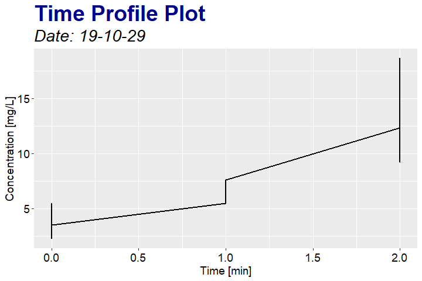

```r
# Map x and y of the plot
tpMapping <- TimeProfileDataMapping$new(x="Time", y="Simulated")

# Define the ggplot object
plotObject <- plotTimeProfile(data=timeProfileDataFrame,
                              metaData = timeProfileMetaData,
                              dataMapping = tpMapping)
# Show plot
plotObject
```

The vertical bars seen in this plot occur because the dataframe `timeProfileDataFrame` has more than one `y` value per time point `x` and no `Grouping` object was supplied in the constructing the `TimeProfileDataMapping` object `tpMapping` so that these `y` values can be separated into different time profiles.

## 5.2. Workflow example of time profile plot using `TimeProfilePlotConfiguration`

This example generates a similar plot to the preceding one, except that here `TimeProfilePlotConfiguration` object `tpConfig` is used to set a custom title and y-axis label.

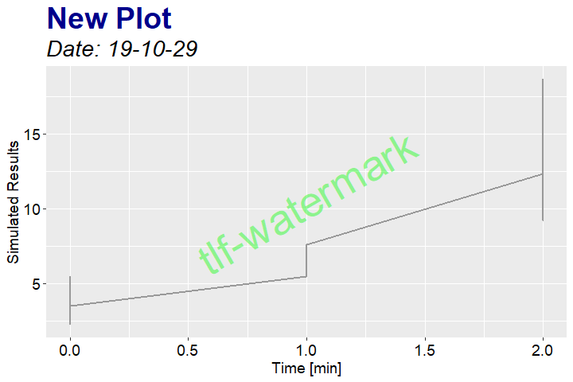

```r
# Set current theme
useTheme(tlfTheme)

# Map x and y of the plot
tpMapping <- TimeProfileDataMapping$new(x="Time", y="Simulated")

# Overwrite plot configuration
tpConfig <- TimeProfilePlotConfiguration$new(title = "New Plot",
                                             ylabel = "Simulated Results",
                                             data = timeProfileDataFrame,
                                             metaData = timeProfileMetaData,
                                             dataMapping = tpMapping)

# Define the ggplot object with updated configuration
plotObject <- plotTimeProfile(data=timeProfileDataFrame,
                              metaData = timeProfileMetaData,
                              dataMapping = tpMapping,
                              plotConfiguration = tpConfig)
# Show plot
plotObject
```

## 5.3. Workflow example of time profile plot using `TimeProfileDataMapping` with `Groupings`

In this example, the vertical bars seen previous examples are removed through the use of a `Grouping` object that assigns a different color to each individual in the `IndividualID` column of `timeProfileDataFrame`, as well as a different linetype for each of the two populations (Asian and European). This separates datapoints coincident in time into separate graphs.

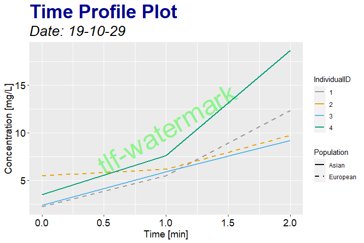

```r
# Map x, y and groups of the plot
groups <- Groupings$new(color = "IndividualID",
                        linetype = "Population")

tpMapping <- TimeProfileDataMapping$new(x = "Time",
                                        y = "Simulated",
                                        groupings = groups)

# Define the ggplot object
plotObject <- plotTimeProfile(data=timeProfileDataFrame,
                              metaData = timeProfileMetaData,
                              dataMapping = tpMapping)

# Show plot
plotObject
```

## 5.4. Workflow example of time profile plot using `TimeProfileDataMapping` with `Groupings` as data.frame

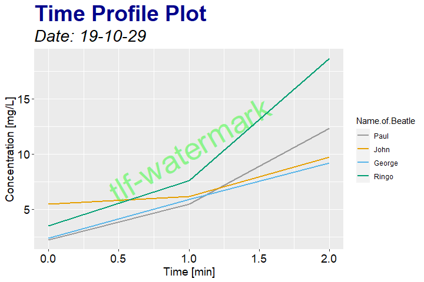

```r
# data.frame associating grouping to Individual ID with their captions
groupingIndividualsDf <- data.frame(IndividualID = c(1,2,3,4) ,
                                    "Name of Beatle" = c("Paul", "John", "George", "Ringo"))
# Define the grouping variable
groups = Groupings$new(color = groupingIndividualsDf)

# Map x, y and groups
tpMapping <- TimeProfileDataMapping$new(x = "Time",
                                        y = "Simulated",
                                        groupings = groups)

# Define the ggplot object
plotObject <- plotTimeProfile(data=timeProfileDataFrame,
                              metaData = timeProfileMetaData,
                              dataMapping = tpMapping)

# Show plot
plotObject
```

## 5.5. Workflow example of time profile plot using `TimeProfileDataMapping` with `AggregationSummary`

### 5.5.1. Plot aggregated mean value

Here, the `AggregationSummary` object is used to aggregate the data in `timeProfileDataFrame` at each timepoint by population and then compute the mean, minimum and maximum of the aggregated data at each of the timepoints. Next, the mean at each timepoint is plotted. Since there are two populations in the “Population” column of `timeProfileDataFrame`, there are two mean values at each timepoint, giving rise to the vertical lines shown in the following plot.

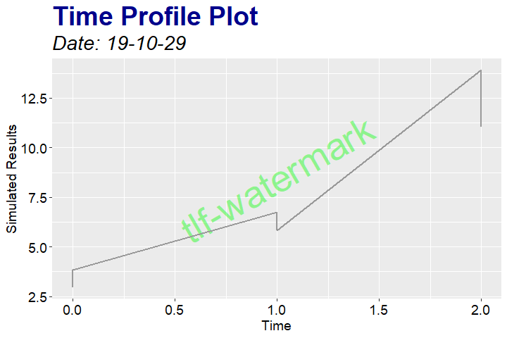

```r
# Define aggregated values through helper

hlp <- AggregationSummary$new(data = timeProfileDataFrame,
                              metaData = timeProfileMetaData,
                              xColumnNames = "Time",
                              groupingColumnNames = c("Population"),
                              yColumnNames = "Simulated",
                              aggregationFunctionsVector = c(mean,min,max),
                              aggregationFunctionNames = c("Simulated Mean",
                                                           "Simulated Min",
                                                           "Simulated Max"),
                              aggregationUnitsVector = c("mg/L","mg/L","mg/L"),
                              aggregationDimensionsVector = c("Concentration",
                                                              "Concentration",
                                                              "Concentration"))

# Map x and y
tpMappingMean <- TimeProfileDataMapping$new(x = "Time",
                                            y = "Simulated Mean")
# Overwrite the plot configuration
tpConfig <-  TimeProfilePlotConfiguration$new(ylabel = "Simulated Results",
                                              xlabel = "Time")

# Define the ggplot object
meanPlot <- plotTimeProfile(data=hlp$dfHelper,
                            dataMapping = tpMappingMean,
                            plotConfiguration = tpConfig)
# Show plot
meanPlot
```

### 5.5.2. Plot aggregated mean value by population

Here, the means generated by the `AggregationSummary` object are grouped by population. The `Groupings` object input to the constructor of the `TimeProfileDataMapping` object `tpMappingMean` specifies that each population should be plotted by a different color.

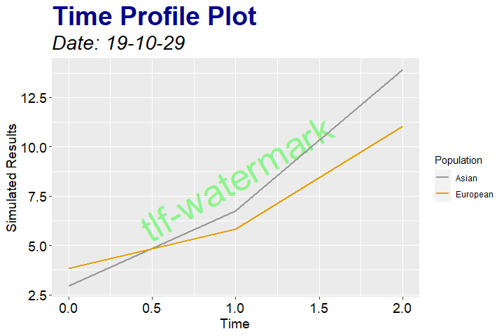

```r
# Map x, y and groupings
tpMappingMean <- TimeProfileDataMapping$new(x = "Time",
                                            y = "Simulated Mean",
                                            groupings = Groupings$new(color = "Population"))

# Overwrite the plot configuration
tpConfig <-  TimeProfilePlotConfiguration$new(ylabel = "Simulated Results",
                                              xlabel = "Time",
                                              data=hlp$dfHelper,
                                              dataMapping = tpMappingMean)

# Define the ggplot object
meanPlot <- plotTimeProfile(data=hlp$dfHelper,
                            dataMapping = tpMappingMean,
                            plotConfiguration = tpConfig)
# Show plot
meanPlot
```

### 5.5.3. Plot aggregated min and max values

In this example, `x`, `yMin` and `yMax` variables are used to construct the `TimeProfileDataMapping` object `tpMappingRange`. Since no `y` variable is supplied, the `plotTimeProfile` function produces a range plot. The “dislocation” in the range plot at time 1 min is due to the fact that the `AggregationSummary` yielded two `yMin` and `yMax` values at each timepoint, one for each population.

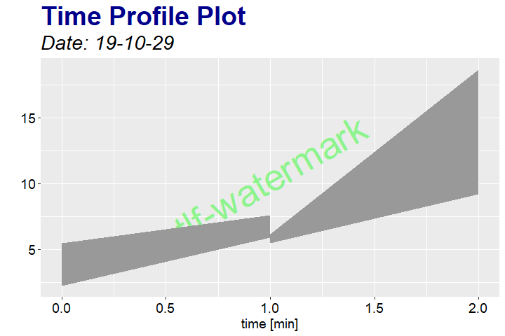

```r
# Map x, yMin and yMax
tpMappingRange <- TimeProfileDataMapping$new(x = "Time",
                                             yMin = "Simulated Min",
                                             yMax = "Simulated Max")

# Overwrite the plot configuration
tpConfig <-  TimeProfilePlotConfiguration$new(ylabel = "Simulated Results",
                                              xlabel = "Time",
                                              data=hlp$dfHelper,
                                              dataMapping = tpMappingRange)

# Define the ggplot object
rangePlot <- plotTimeProfile(data=hlp$dfHelper,
                             dataMapping = tpMappingRange)

# Show plot
rangePlot
```

### 5.5.4. Plot aggregated min and max values by population

This example adds a grouping by population to the `TimeProfileDataMapping` object `tpMappingRange`. This results in two range plots, where the fill color distinguishes between the Asian and European population values.

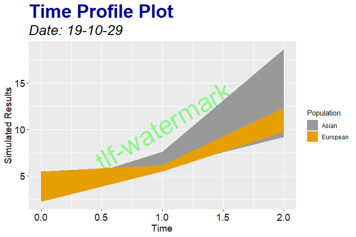

```r
# Map x, yMin and yMax
tpMappingRange <- TimeProfileDataMapping$new(x = "Time",
                                             yMin = "Simulated Min",
                                             yMax = "Simulated Max",
                                             groupings = Groupings$new(fill = "Population"))

# Overwrite the plot configuration
tpConfig <-  TimeProfilePlotConfiguration$new(ylabel = "Simulated Results",
                                              xlabel = "Time",
                                              data=hlp$dfHelper,
                                              dataMapping = tpMappingRange)

# Define the ggplot object
rangePlot <- plotTimeProfile(data=hlp$dfHelper,
                             dataMapping = tpMappingRange,
                             plotConfiguration = tpConfig)

# Show plot
rangePlot
```

### 5.5.5. Plot aggregated mean, min, max values by population

With respect to the previous example, here, a `y` variable is added to the `TimeProfileDataMapping` object resulting in the `plotTimeProfile` returning a time profile plot with error bars. Note that the `Groupings` object in the `TimeProfileDataMapping` object constructor specifies that each population should be distinguished by color.

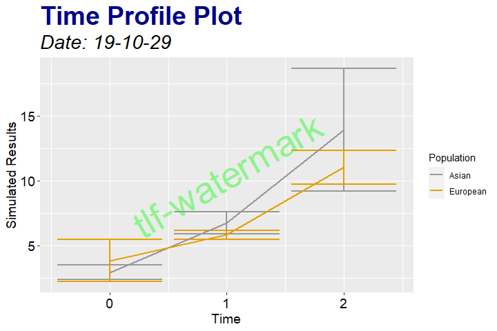

```r
# Map x, y, yMin and yMax
tpMappingErrorBar <- TimeProfileDataMapping$new(x = "Time",
                                                y = "Simulated Mean",
                                                yMin = "Simulated Min",
                                                yMax = "Simulated Max",
                                                groupings = Groupings$new(color = "Population"))

# Overwrite the plot configuration
tpConfig <-  TimeProfilePlotConfiguration$new(ylabel = "Simulated Results",
                                              xlabel = "Time",
                                              data=hlp$dfHelper,
                                              dataMapping = tpMappingErrorBar)

# Define the ggplot object
errorBarPlot <- plotTimeProfile(data=hlp$dfHelper,
                                dataMapping = tpMappingErrorBar,
                                plotConfiguration = tpConfig)

# Show plot
errorBarPlot
```